# Inputs and plots for Fig 2 (GSFA)

Joe Bowness

February 06, 2026

Abstract

This records the preprocessing for GSFA, and then loading and plotting the results.

## 0.1 path to analysis

```r
#path_to_analysis <- "/users/lvelten/jbowness/CRISPRi500/HSC/clean_analysis/"
path_to_analysis <- "~/cluster/jbowness/CRISPRi500/HSC/clean_analysis/"
```

## 0.2 Required packages

```r
knitr::opts_chunk$set(message = FALSE, warning = FALSE)

#load packages
library(GSFA)
library(readr)
library(Seurat)
library(ggplot2)
library(tidyr)
library(dplyr)
library(patchwork)
library(ggrepel)
library(WebGestaltR)
library(clusterProfiler)
library(scales)
library(stringr)
library(gridExtra)
library(enrichplot)
library(plotly)
library(ComplexHeatmap)

#Lars' hsc18 package
#library(hsc18)
```

# 1 Get inputs for GSFA

- See https://xinhe-lab.github.io/GSFA_paper/preprocess_and_gsfa_TCells.html#26_Inputs_for_GSFA
- Make the input files from the PRTB assay (this format is in a similar form as a Z score..)
- Subset only by consistent guides, which actually removes the non-targeting controls as well. For the PRTB assay maybe this is OK, because in theory each cell is already scaled compared to nearest NT controls.

## 1.1 Subset seurat object to only consistent perturbations

```r
# load seurat object
CRISPRi500_HSC <- readRDS(paste0(path_to_analysis, "seurat_objects/CRISPRi500_HSC_WTx_prtb.RDS"))

# subset seurat object to only consistent genes
consistent_genes <- read_csv(paste0(path_to_analysis, "manuscript/int_files/SGS_gene_prtb_filt_pearson.csv"))
consistent_guides <- read_csv(paste0(path_to_analysis, "manuscript/int_files/SGS_guide_prtb_filt_pearson.csv"))

# make single target column
CRISPRi500_HSC@meta.data$singletarget <- sub("-.*", "", CRISPRi500_HSC@meta.data$single_guides)
CRISPRi500_HSC@meta.data$singletarget[grepl("NO|ONE", CRISPRi500_HSC@meta.data$singletarget)] <- "Non-targeting"

# subset seurat object by consistent genes
CRISPRi500_HSC_consistent <- subset(CRISPRi500_HSC, singletarget %in% consistent_genes$Gene)
```

## 1.2 Extract the scaled PRTB matrix only from consistent perturbations

```r
scaled.gene_exp <- CRISPRi500_HSC_consistent@assays$prtb@scale.data
cell_names <- colnames(CRISPRi500_HSC_consistent@assays$prtb@scale.data)
gene_names <- rownames(CRISPRi500_HSC_consistent@assays$prtb@scale.data)
colnames(scaled.gene_exp) <- cell_names
rownames(scaled.gene_exp) <- gene_names
scaled.gene_exp <- t(scaled.gene_exp)

# save scaled PRTB matrix
saveRDS(scaled.gene_exp,
        file = paste0(path_to_analysis,"manuscript/int_files/GSFA_inputs/CRISPRi500_HSC_consistent_prtb.rds"))
```

## 1.3 Extract a Gmat from the CROP assay in seurat object

```r
# get G matrix (binary of CROP matrix?)
G_mat <- t(CRISPRi500_HSC_consistent@assays[["CROP"]]@counts)

G_mat@x[G_mat@x == 1] <- 0
G_mat@x[G_mat@x >= 2] <- 1
G_mat <- as.matrix(G_mat)
nonzero_cols <- Matrix::colSums(G_mat != 0) > 0
G_mat <- G_mat[, nonzero_cols, drop = FALSE]

# make matrix by gene instead guide, also collapse non-targeting guides
gene_names <- sub("-CRISPRi-sgRNA-.*", "", colnames(G_mat))
gene_names[grepl("ONE-INTERGENIC-sgRNA-|NO-SITE-sgRNA-", colnames(G_mat))] <- "Non-targeting"
G_t <- t(G_mat)
G_mat_by_gene <- rowsum(G_t, group = gene_names)
G_mat_by_gene <- t((G_mat_by_gene > 0) * 1)
rm(G_t)

num_cells <- colSums(G_mat_by_gene)
num_cells_df <- data.frame(locus = names(num_cells),
                           count = num_cells)

# by guide
num_cells_guide <- colSums(G_mat)
num_cells_guide_df <- data.frame(locus = names(num_cells_guide),
                           count = num_cells_guide)

# save G_mat (by guide and by gene)
saveRDS(G_mat,
        file = paste0(path_to_analysis, "manuscript/int_files/GSFA_inputs/CRISPRi500_HSC_consistent_guide_Gmat.rds"))
saveRDS(G_mat_by_gene,
        file = paste0(path_to_analysis, "manuscript/int_files/GSFA_inputs/CRISPRi500_HSC_consistent_gene_Gmat.rds"))

# save data frames of cells pr guide/gene
write.csv(num_cells_df,
          paste0(path_to_analysis, "manuscript/int_files/GSFA_inputs/CRISPRi500_HSC_consistent_gene_cells_per_gene.rds"), row.names = FALSE)
write.csv(num_cells_guide_df,
          paste0(path_to_analysis, "manuscript/int_files/GSFA_inputs/CRISPRi500_HSC_consistent_cells_per_guide.rds"), row.names = FALSE)
```

# 2 Now run GSFA with run_GSFA.R script (on cluster)

# 3 GSFA factors = GRPs

## 3.1 Load results from GSFA

- We decided to use the output from GSFA using 21 factors. The rationale behind this is explained in GSFA_num_of_factors.Rmd ; basically a balance between interpretability and proportion variance explained (PVE) by the factors.

```r
# G_mat
G_mat_guide <- readRDS(
  paste0(path_to_analysis, "manuscript/int_files/GSFA_inputs/CRISPRi500_HSC_consistent_guide_Gmat.rds"))

perturbation_guide_names <- colnames(G_mat_guide)

# ---- Load GSFA results with 21 factors ----
fit21 <- readRDS(paste0(path_to_analysis, "manuscript/int_files/GSFA_outputs/fit_guide_consistent_21.rds"))
gibbs_PM_21 <- fit21$posterior_means

effect_mat_21 <- fit21$total_effect[, -ncol(fit21$total_effect)] # remove 'offset' column
lfsr_mat_21 <- fit21$lfsr[, -ncol(fit21$lfsr)] # remove 'offset' column

PIP_mat_21 <- gibbs_PM_21$F_pm
W_mat_21 <- gibbs_PM_21$W_pm

# Make W matrix sparse (PIP > 0.8)
W_mat_21_sparse <- W_mat_21
W_mat_21_sparse[PIP_mat_21 < 0.8] <- 0
```

## 3.2 Functions for exploring factors

```r
# swap signs function
flip_W_by_majority_sign <- function(W, ties = c("keep", "flip")) {
  ties <- match.arg(ties)
  K <- ncol(W)
  fac_names <- colnames(W)
  if (is.null(fac_names)) fac_names <- paste0("Factor_", seq_len(K))

  multiply_by <- rep(1L, K)

  if (inherits(W, "dgCMatrix")) {
    # sparse path
    W_out <- W
    p <- W@p
    for (j in seq_len(K)) {
      idx <- if (p[j] < p[j + 1]) (p[j] + 1L):p[j + 1L] else integer(0)
      v <- if (length(idx)) W@x[idx] else numeric(0)
      n_pos <- sum(v > 0, na.rm = TRUE)
      n_neg <- sum(v < 0, na.rm = TRUE)
      if (n_neg > n_pos || (n_neg == n_pos && ties == "flip")) {
        multiply_by[j] <- -1L
        if (length(idx)) W_out@x[idx] <- -W_out@x[idx]
      }
    }
    colnames(W_out) <- fac_names
  } else {
    # dense path
    M <- as.matrix(W)
    for (j in seq_len(K)) {
      v <- M[, j]
      n_pos <- sum(v > 0, na.rm = TRUE)
      n_neg <- sum(v < 0, na.rm = TRUE)
      if (n_neg > n_pos || (n_neg == n_pos && ties == "flip")) {
        multiply_by[j] <- -1L
        M[, j] <- -M[, j]
      }
    }
    colnames(M) <- fac_names
    W_out <- M
  }

  tbl <- data.frame(factor_id = fac_names, multiply_with = multiply_by, row.names = NULL)
  print(tbl)

  invisible(list(W_flipped = W_out, multiply_table = tbl))
}
# plot heatmap function
plot_W_heatmap <- function(W,
                               remove_factors = c(1, 2),
                               low = "blue", mid = "white", high = "red",
                               base_size = 10) {

  # Coerce to sparse genes × factors
  W <- Matrix::Matrix(as.matrix(W), sparse = TRUE)

  K <- ncol(W)
  keep_cols <- setdiff(seq_len(K), intersect(remove_factors, seq_len(K)))

  # Subset to kept factors
  Wk <- W[, keep_cols, drop = FALSE]

  # Keep only genes with any nonzero loading
  use <- Matrix::rowSums(Wk != 0) > 0
  if (!any(use)) stop("No genes with non-zero loadings after filtering.")
  Wk <- Wk[use, , drop = FALSE]

  # Dense for ordering/plotting
  Wd <- as.matrix(Wk)

  # For each gene: factor of max |loading| and its value
  gene2fac <- max.col(abs(Wd), ties.method = "first")
  gene_val <- Wd[cbind(seq_len(nrow(Wd)), gene2fac)]

  # abs_desc ordering within each factor
  gene_order <- order(gene2fac, -gene_val)
  gene_levels <- rownames(Wd)[gene_order]

  # Long format
  df_long <- Wd |>
    as.data.frame() |>
    tibble::rownames_to_column("gene") |>
    tidyr::pivot_longer(cols = -gene, names_to = "factor_id", values_to = "value")

  # Axes ordering (top row shows highest-index factor)
  df_long$factor_id <- factor(df_long$factor_id, levels = rev(colnames(Wd)))
  df_long$gene      <- factor(df_long$gene,      levels = gene_levels)

  # Plot
  ggplot2::ggplot(df_long, ggplot2::aes(x = gene, y = factor_id, fill = value)) +
    ggplot2::geom_tile() +
    ggplot2::scale_fill_gradient2(low = low, mid = mid, high = high, name = "Loading") +
    ggplot2::theme_minimal(base_size = base_size) +
    ggplot2::theme(
      axis.text.x = ggplot2::element_blank(),
      axis.ticks.x = ggplot2::element_blank(),
      panel.grid   = ggplot2::element_blank()
    ) +
    ggplot2::xlab(sprintf("Genes (n=%d)", nrow(Wd))) +
    ggplot2::ylab("Factor")
}

# compare two heatmaps function
plot_W_compare_heatmaps <- function(W1, W2,
                                    remove_factors = c(1, 2),
                                    matrix_names = c("W1", "W2"),
                                    low = "blue", mid = "#EEEEEE", high = "red",
                                    base_size = 10) {
  stopifnot(length(matrix_names) == 2)
  stopifnot(requireNamespace("Matrix", quietly = TRUE),
            requireNamespace("tibble", quietly = TRUE),
            requireNamespace("tidyr", quietly = TRUE),
            requireNamespace("ggplot2", quietly = TRUE),
            requireNamespace("patchwork", quietly = TRUE))

  as_sparse <- function(W) {
    W <- Matrix::Matrix(as.matrix(W), sparse = TRUE)
    if (is.null(rownames(W))) rownames(W) <- paste0("gene_", seq_len(nrow(W)))
    if (is.null(colnames(W))) colnames(W) <- paste0("Factor_", seq_len(ncol(W)))
    W
  }
  drop_factors <- function(W, rm_idx) {
    keep <- setdiff(seq_len(ncol(W)), intersect(rm_idx, seq_len(ncol(W))))
    W[, keep, drop = FALSE]
  }
  # align to a fixed gene order by writing into a preallocated zero sparse matrix
  align_genes <- function(W, genes) {
    Z <- Matrix::Matrix(0, nrow = length(genes), ncol = ncol(W), sparse = TRUE,
                        dimnames = list(genes, colnames(W)))
    idx <- match(rownames(W), genes)
    Z[idx, ] <- W
    Z
  }
  to_long <- function(M, tag) {
    df <- as.data.frame(as.matrix(M))
    df <- tibble::rownames_to_column(df, "gene")
    df <- tidyr::pivot_longer(df, -gene, names_to = "factor_id", values_to = "value")
    df$factor_id <- paste0(df$factor_id, " (", tag, ")")
    df
  }

  # Prep & filter
  W1 <- drop_factors(as_sparse(W1), remove_factors)
  W2 <- drop_factors(as_sparse(W2), remove_factors)
  use1 <- Matrix::rowSums(W1 != 0) > 0
  use2 <- Matrix::rowSums(W2 != 0) > 0
  if (!any(use1) && !any(use2)) stop("No non-zero genes after removing factors.")

  if (any(use1)) W1 <- W1[use1, , drop = FALSE]
  if (any(use2)) W2 <- W2[use2, , drop = FALSE]

  # Order genes in W1: group by factor of max |loading|, then DESC by signed loading
  W1d <- as.matrix(W1)
  g2f1 <- max.col(abs(W1d), ties.method = "first")
  val1 <- W1d[cbind(seq_len(nrow(W1d)), g2f1)]
  genes_W1_ordered <- rownames(W1d)[order(g2f1, -val1)]

  # Genes only in W2 (not in W1 after filtering)
  genes_W2_only <- setdiff(rownames(W2), rownames(W1))
  if (length(genes_W2_only)) {
    W2_sub <- as.matrix(W2[genes_W2_only, , drop = FALSE])
    g2f2 <- max.col(abs(W2_sub), ties.method = "first")
    val2 <- W2_sub[cbind(seq_len(nrow(W2_sub)), g2f2)]
    genes_W2_only_ordered <- genes_W2_only[order(g2f2, -val2)]
  } else {
    genes_W2_only_ordered <- character(0)
  }

  # Final x-axis order: all W1 genes first, then W2-only genes
  gene_levels <- c(genes_W1_ordered, genes_W2_only_ordered)
```

```r
  # Align both matrices to this x-axis (zeros for missing genes)
  W1a <- align_genes(W1, gene_levels)
  W2a <- align_genes(W2, gene_levels)

  # Long data for plotting
  df1 <- to_long(W1a, matrix_names[1])
  df2 <- to_long(W2a, matrix_names[2])

  # Y axis levels (top-to-bottom = higher factor index to lower)
  lev1 <- rev(paste0(colnames(W1a), " (", matrix_names[1], ")"))
  lev2 <- rev(paste0(colnames(W2a), " (", matrix_names[2], ")"))
  df1$factor_id <- factor(df1$factor_id, levels = lev1)
  df2$factor_id <- factor(df2$factor_id, levels = lev2)

  # X axis order fixed by gene_levels from W1, then W2-only
  df1$gene <- factor(df1$gene, levels = gene_levels)
  df2$gene <- factor(df2$gene, levels = gene_levels)

  # Plots
  p_top <- ggplot2::ggplot(df1, ggplot2::aes(gene, factor_id, fill = value)) +
    ggplot2::geom_tile() +
    ggplot2::scale_fill_gradient2(low = low, mid = mid, high = high, name = "Loading") +
    ggplot2::theme_minimal(base_size = base_size) +
    ggplot2::theme(axis.text.x = ggplot2::element_blank(),
                   axis.ticks.x = ggplot2::element_blank(),
                   panel.grid  = ggplot2::element_blank()) +
    ggplot2::labs(x = sprintf("Genes (union, n=%d)", length(gene_levels)),
                  y = NULL, title = matrix_names[1])

  p_bot <- ggplot2::ggplot(df2, ggplot2::aes(gene, factor_id, fill = value)) +
    ggplot2::geom_tile() +
    ggplot2::scale_fill_gradient2(low = low, mid = mid, high = high, name = "Loading") +
    ggplot2::theme_minimal(base_size = base_size) +
    ggplot2::theme(axis.text.x = ggplot2::element_blank(),
                   axis.ticks.x = ggplot2::element_blank(),
                   panel.grid  = ggplot2::element_blank()) +
    ggplot2::labs(x = NULL, y = NULL, title = matrix_names[2])

  ((p_top / p_bot) +
     patchwork::plot_layout(guides = "collect")) &
    ggplot2::theme(legend.position = "right")
}

# plot pairwise correlation between factors function (taken from GSFA_paper GitHub)
plot_pairwise.corr_heatmap_reorder <- function(input_mat_1, input_mat_2 = NULL,
                                       name_1 = NULL, name_2 = NULL,
                                       corr_type = c("pearson", "jaccard", "prop_overlap"),
                                       return_corr = FALSE,
                                       label_size = 8,
                                       color_vec = NULL,
                                       reorder_diag = c("none","closest_to_1","closest_to_-1","absmax")){
  # Please store samples in the columns of 'input_mat'.
  reorder_diag <- match.arg(reorder_diag)
  if (is.null(input_mat_2)){
    input_mat_2 <- input_mat_1
  }
  if (is.null(name_2)){
    name_2 <- name_1
  }
  stopifnot(nrow(input_mat_1) == nrow(input_mat_2))
  corr_mat <- matrix(nrow = ncol(input_mat_1), ncol = ncol(input_mat_2))

  for (i in 1:ncol(input_mat_1)){
    for (j in 1:ncol(input_mat_2)){
      vec_1 <- input_mat_1[, i]
      vec_2 <- input_mat_2[, j]
      if (corr_type == "pearson"){
        corr_mat[i, j] <- cor(vec_1, vec_2, method = "pearson")
      } else if (corr_type == "jaccard"){
        corr_mat[i, j] <- sum(vec_1 * vec_2) / sum((vec_1 + vec_2) > 0)
      } else {
        corr_mat[i, j] <- sum(vec_1 * vec_2) / sum(vec_1)
      }
    }
  }

  if (is.null(colnames(input_mat_1))){
    rownames(corr_mat) <- 1:ncol(input_mat_1)
  } else {
    rownames(corr_mat) <- colnames(input_mat_1)
  }
  if (is.null(colnames(input_mat_2))){
    colnames(corr_mat) <- 1:ncol(input_mat_2)
  } else {
    colnames(corr_mat) <- colnames(input_mat_2)
  }

  # --------- NEW: optimal reordering that KEEPS RECTANGULAR SHAPE ---------
  if (reorder_diag != "none"){
    M <- corr_mat
    # Build a cost matrix for LSAP (minimization)
    if (reorder_diag == "closest_to_1") {
      cost <- 1 - M
    } else if (reorder_diag == "closest_to_-1") {
      cost <- 1 + M
    } else { # "absmax"
      cost <- 1 - abs(M)
    }
    n1 <- nrow(cost); n2 <- ncol(cost)

    # Pad to square only for solving the assignment
    k <- max(n1, n2)
    pad_val <- max(cost, na.rm = TRUE) + 1
    cost_sq <- matrix(pad_val, nrow = k, ncol = k)
    cost_sq[1:n1, 1:n2] <- cost

    get_assignment <- function(cost_matrix){
      if (requireNamespace("clue", quietly = TRUE)) {
        as.integer(clue::solve_LSAP(cost_matrix))
      } else {
        # Greedy fallback if 'clue' is not installed
        warning("Package 'clue' not installed; using greedy matching.")
        assign <- integer(nrow(cost_matrix))
        remaining <- seq_len(ncol(cost_matrix))
        for (i in seq_len(nrow(cost_matrix))) {
          j_idx <- remaining[ which.min(cost_matrix[i, remaining]) ]
          assign[i] <- j_idx
          remaining <- setdiff(remaining, j_idx)
          if (!length(remaining)) break
        }
        assign
      }
    }

    ass <- get_assignment(cost_sq)[seq_len(n1)]  # chosen column for each row (in padded square)

    if (n1 <= n2) {
      # Reorder COLUMNS: put matched columns (in row order) first, then the rest
      matched_cols <- ass[ass <= n2]
      matched_cols <- unique(matched_cols)  # just in case
      rest_cols <- setdiff(seq_len(n2), matched_cols)
      new_col_order <- c(matched_cols, rest_cols)
      corr_mat <- M[, new_col_order, drop = FALSE]
      attr(corr_mat, "col_order") <- new_col_order
    } else {
      # Reorder ROWS: place rows by the column they were matched to, then append unmatched rows
      matched_rows <- which(ass <= n2)
      row_order_first <- matched_rows[order(ass[matched_rows])]
      rest_rows <- setdiff(seq_len(n1), row_order_first)
      new_row_order <- c(row_order_first, rest_rows)
      corr_mat <- M[new_row_order, , drop = FALSE]
      attr(corr_mat, "row_order") <- new_row_order
    }
  }
  # ------------------------------------------------------------------------

  if (corr_type == "pearson"){
    legend_name <- "Pearson Correlation"
    if (is.null(color_vec)){
      colormap <- circlize::colorRamp2(breaks = c(-1, 0, 1),
                                       colors = c("blue", "white", "red"))
    } else {
      colormap <- circlize::colorRamp2(breaks = c(-1, 0, 1),
                                       colors = color_vec)
    }
  }
  if (corr_type == "jaccard" | corr_type == "prop_overlap"){
    legend_name <- ifelse(corr_type == "jaccard",
                          "Jaccard Index", "% of Shared Non-Zero Genes")
    if (is.null(color_vec)){
      colormap <- circlize::colorRamp2(breaks = c(0, 0.3, 1),
                                       colors = c("black", "purple", "gold"))
    } else {
      colormap <- circlize::colorRamp2(breaks = c(0, 0.5, 1),
                                       colors = color_vec)
    }
  }
```

```r
  ht <- Heatmap(corr_mat,
                col = colormap,
                name = legend_name,
                row_title = name_1, column_title = name_2,
                cluster_rows = FALSE, cluster_columns = FALSE,
                row_names_gp = gpar(fontsize = label_size),
                column_names_gp = gpar(fontsize = label_size))
  draw(ht)
  if (return_corr){
    return(corr_mat)
  }
}

# get top and bottom genes for a given factor
get_genes_for_factor <- function(factor_name, W, top = FALSE, eps = 0) {
  stopifnot(factor_name %in% colnames(W))
  a <- setNames(as.numeric(W[, factor_name]), rownames(W))
  if (top) a <- a[a >  eps] else a <- a[a < -eps]
  names(sort(a, decreasing = top))
}

# zoom in on particular factor in the heatmap
zoom_factor_heatmap_W <- function(W,
                                  target_factor,
                                  genes_to_label = character(),
                                  eps = 0,
                                  reorder_by_strength = TRUE,
                                  show_x_labels = FALSE) {
  # deps
  stopifnot(requireNamespace("ggplot2", quietly = TRUE),
            requireNamespace("ggrepel", quietly = TRUE))
  if (!inherits(W, "matrix") && !inherits(W, "dgCMatrix")) {
    if (requireNamespace("Matrix", quietly = TRUE)) {
      W <- Matrix::Matrix(as.matrix(W), sparse = TRUE)
    } else {
      W <- as.matrix(W)
    }
  }

  # ensure names
  if (is.null(rownames(W))) rownames(W) <- paste0("gene_", seq_len(nrow(W)))
  if (is.null(colnames(W))) colnames(W) <- paste0("Factor_", seq_len(ncol(W)))

  # resolve which factor to plot (accept numeric index or name like "Factor_3")
  if (is.numeric(target_factor) && length(target_factor) == 1L) {
    j <- as.integer(target_factor)
  } else if (is.character(target_factor) && length(target_factor) == 1L) {
    j <- match(target_factor, colnames(W))
    if (is.na(j)) {
      # try to parse trailing number if given "Factor_3" style
      num <- suppressWarnings(as.integer(gsub("\\D", "", target_factor)))
      if (!is.na(num)) j <- num
    }
  } else {
    stop("`target_factor` must be a single numeric index or a single column name.")
  }
  if (is.na(j) || j < 1L || j > ncol(W)) stop("`target_factor` does not match any column of W.")

  fac_label <- colnames(W)[j]
  vals <- as.numeric(W[, j])
  genes <- rownames(W)

  # filter by |value| > eps
  keep <- abs(vals) > eps
  if (!any(keep)) stop(sprintf("No genes with |loading| > %g for %s.", eps, fac_label))

  df <- data.frame(
    gene      = genes[keep],
    factor_id = fac_label,
    value     = vals[keep],
    stringsAsFactors = FALSE
  )

  # order genes (optional): DESC by signed loading (most positive → most negative)
  if (isTRUE(reorder_by_strength)) {
    df <- df[order(-df$value), , drop = FALSE]
  }

  # factor levels for axes
  df$gene      <- factor(df$gene,      levels = df$gene)          # left→right as ordered above
  df$factor_id <- factor(df$factor_id, levels = fac_label)        # single strip

  # small display constants
  aspect_ratio  <- 0.2 # was 0.12
  label_nudge_y <- 2
  y_expand_top  <- 1.2 # was 0.25
  label_size    <- 2.8
  repel_force   <- 2  # was 2
  arrow_len_npc <- 0.05

  p <- ggplot2::ggplot(df, ggplot2::aes(x = gene, y = factor_id, fill = value)) +
    ggplot2::geom_tile(height = 0.9) +
    ggplot2::scale_fill_gradient2(low = "blue", mid = "#EEEEEE", high = "red", name = "Loading") +
    ggplot2::scale_y_discrete(expand = ggplot2::expansion(mult = c(0.05, y_expand_top))) +
    ggplot2::theme_minimal(base_size = 10) +
    ggplot2::theme(
      panel.grid = ggplot2::element_blank(),
      axis.title.y = ggplot2::element_text(),
      axis.text.y  = ggplot2::element_blank(),
      axis.ticks.y = ggplot2::element_blank(),
      axis.text.x  = if (show_x_labels) ggplot2::element_text(angle = 90, vjust = 0.5, hjust = 1)
                     else ggplot2::element_blank(),
      axis.ticks.x = if (show_x_labels) ggplot2::element_line() else ggplot2::element_blank(),
      plot.margin  = ggplot2::margin(t = 10, r = 8, b = 6, l = 8),
      aspect.ratio = aspect_ratio
    ) +
    ggplot2::xlab(sprintf("Genes loaded to %s", fac_label)) +
    ggplot2::ylab(fac_label) +
    ggplot2::coord_cartesian(clip = "off")

  # optional labels
  if (length(genes_to_label)) {
    lab_df <- df[df$gene %in% genes_to_label, , drop = FALSE]
    if (nrow(lab_df)) {
      p <- p + ggrepel::geom_text_repel(
        data = lab_df,
        ggplot2::aes(label = gene),
        direction = "y",
        nudge_y = label_nudge_y,
        force = repel_force,
        max.overlaps = Inf,
        min.segment.length = 0,
        segment.size = 0.3,
        segment.alpha = 0.8,
        arrow = ggplot2::arrow(length = grid::unit(arrow_len_npc, "npc")),
        box.padding = 0.15,
        point.padding = 0.15,
        size = label_size,
        seed = 9
      )
    }
  }

  p
}

# barplots of top enriched GO terms (from GSFA paper)
barplot_top_enrich_terms <- function(enrich_df, fdr_cutoff = 0.05, FC_cutoff = 2,
                                     size_cutoff = 20,
                                     terms_of_interest = NULL,
                                     top_num = 5,
                                     str_wrap_length = 25,
                                     FC_max = 8,
                                     pval_max = 10){
  enrich_df <- enrich_df %>%
    filter(FDR < fdr_cutoff, enrichmentRatio >= FC_cutoff) %>%
    filter(size >= size_cutoff) %>%
    arrange(-enrichmentRatio)
  if (is.null(terms_of_interest)){
    top_terms_df <- enrich_df %>% slice(1:top_num)
  } else {
    top_terms_df <- enrich_df %>% filter(description %in% terms_of_interest)
  }
  top_terms_df$description_short <- str_wrap(top_terms_df$description, width = str_wrap_length)
  top_terms_df$description_short <- factor(top_terms_df$description_short,
                                           levels = top_terms_df$description_short)
  top_terms_df$pValue[top_terms_df$pValue < 10^(-pval_max)] <- 10^(-pval_max)
  top_terms_df$enrichmentRatio[top_terms_df$enrichmentRatio > FC_max] <- FC_max
  plot_out <- ggplot(top_terms_df) +
    geom_bar(aes(x = description_short, y = enrichmentRatio, fill = -log10(pValue)),
             stat="identity") +
    coord_flip() +
    scale_y_continuous(limits = c(0, FC_max)) +
    scale_fill_gradientn(limits = c(2, pval_max),
                         colors = c("blue", "red"),
                         breaks = seq(2, pval_max, 2)) +
    theme(axis.title.y = element_blank(),
          axis.text.y = element_text(size = 8))
  return(plot_out)
}
```

## 3.3 Plot a heatmap of the factors

```r
# median genes loaded to each factor
n_nonzero_by_col <- colSums(W_mat_21_sparse != 0 & !is.na(W_mat_21_sparse))
median(n_nonzero_by_col)
```

```
## [1] 89
```

```r
# initial heatmap
initial_heatmp <- plot_W_heatmap(W_mat_21_sparse, remove_factors = NULL)
res <- flip_W_by_majority_sign(W_mat_21_sparse)
```

```
##    factor_id multiply_with
## 1   Factor_1            -1
## 2   Factor_2             1
## 3   Factor_3             1
## 4   Factor_4             1
## 5   Factor_5            -1
## 6   Factor_6             1
## 7   Factor_7             1
## 8   Factor_8            -1
## 9   Factor_9             1
## 10 Factor_10             1
## 11 Factor_11            -1
## 12 Factor_12             1
## 13 Factor_13            -1
## 14 Factor_14             1
## 15 Factor_15            -1
## 16 Factor_16             1
## 17 Factor_17            -1
## 18 Factor_18             1
## 19 Factor_19             1
## 20 Factor_20            -1
## 21 Factor_21             1
```

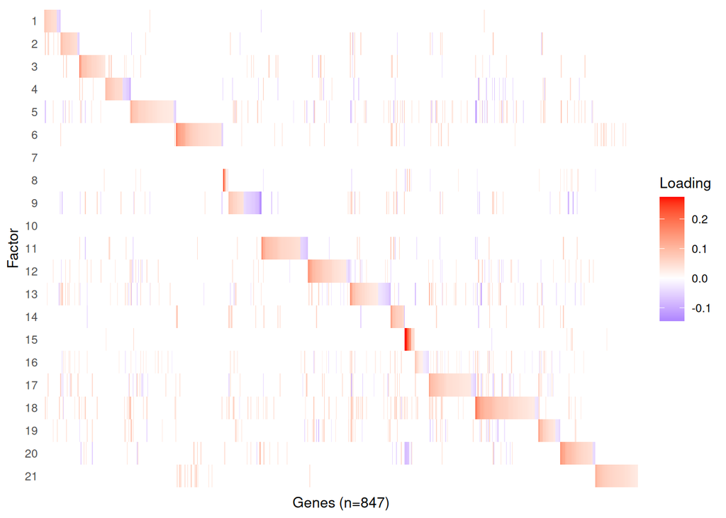

```r
# flip signs and generate multiply_with
W_mat_21_sparse_flip <- res$W_flipped
W_mat_21_mutliply_with <- res$multiply_table

# add GRP name column
factor_annotation_GRP21 <- W_mat_21_mutliply_with
fact_num <- as.integer(sub("Factor_", "", factor_annotation_GRP21$factor_id))
skip <- c(7, 10)
grp_index <- cumsum(!fact_num %in% skip)
grp_index[fact_num %in% skip] <- NA
factor_annotation_GRP21$GRP <- ifelse(is.na(grp_index), NA, paste0("GRP", grp_index))

#rename colnames in plot
W_mat_21_sparse_flip_plot <- W_mat_21_sparse_flip
colnames(W_mat_21_sparse_flip_plot) <-
  gsub("^Factor_", "", colnames(W_mat_21_sparse_flip_plot))

W_mat_heatmap_GSFA21 <- plot_W_heatmap(W_mat_21_sparse_flip_plot,
                                       remove_factors = NULL)
W_mat_heatmap_GSFA21
```

```r
ggsave( filename = "manuscript/fig2/W_mat_heatmap_GSFA21.pdf",
        plot     = W_mat_heatmap_GSFA21,
        width    = 6.5,
        height   = 5,
        units    = "in"
        )
```

## 3.4 Get top and bottom gene lists for each factor

```r
# write gene lists from all factors to files
for (i in 1:21) {
  bottom <- get_genes_for_factor(sprintf("Factor_%d",i), W_mat_21_sparse_flip, top=F)
  top <- get_genes_for_factor(sprintf("Factor_%d",i), W_mat_21_sparse_flip, top=T)
  writeLines(bottom,
               sprintf(paste0(path_to_analysis, "manuscript/int_files/GSFA_factor_gene_lists/Factor_%d_bottom.txt",i)))
  writeLines(top,
               sprintf(paste0(path_to_analysis, "manuscript/int_files/GSFA_factor_gene_lists/Factor_%d_top.txt",i)))
}
```

## 3.5 Plot representative genes for example factors

```r
# Factor 20 = biosynthesis
top_Factor_20 <- get_genes_for_factor("Factor_20", W_mat_21_sparse_flip, top=T)
top_Factor_20
```

```
##  [1] "Hsp90ab1"  "Actb"      "Rps18"     "Rps5"      "Npm1"      "Rpl4"
##  [7] "Rps3"      "B2m"       "Ncl"       "Rps26"     "Pabpc1"    "Tmsb4x"
## [13] "Pdia3"     "Calr"      "Cfl1"      "Ftl1"      "Eef2"      "Fth1"
## [19] "Eef1a1"    "Hsp90b1"   "Canx"      "Rplp1"     "Hspa5"     "Laptm5"
## [25] "Ifitm1"    "Nedd4"     "Rpl37a"    "Eif3a"     "Scd2"      "Pfn1"
## [31] "Hnrnpa2b1" "Gnas"      "Paics"     "Ly6e"      "Nap1l1"    "Itm2b"
## [37] "Sf3b2"     "Hnrnpk"    "Tln1"      "Coro1a"    "Macroh2a1" "Cers6"
## [43] "Srgn"      "Vim"       "Arpc2"     "Aldoa"     "Rpl10"     "Cct5"
## [49] "Cox4i1"    "Flna"      "Rps27"     "Chd4"      "Nop53"     "Gas5"
## [55] "Mef2c"     "Trp53"     "Tax1bp1"   "Lmo2"      "Rbbp7"     "Rps13"
## [61] "Ddx5"      "Mlec"      "Eif4g2"    "Caprin1"   "Emilin2"   "mt-Cytb"
## [67] "Cnbp"      "Pdcd4"
```

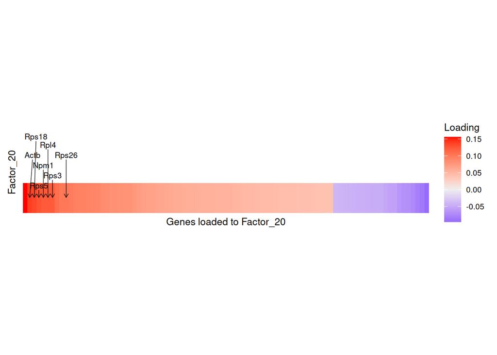

```r
Factor20_biosynthesis <- zoom_factor_heatmap_W(W_mat_21_sparse_flip, target_factor = "Factor_20",
                                               genes_to_label = c("Actb", "Rps18", "Rps5", "Npm1", "Rpl4", "Rps3", "Rps26"), eps = 0.0)
Factor20_biosynthesis
```

```r
# Factor 17 = LT-HSC  vs Lymphoid priming
top_Factor_17 <- get_genes_for_factor("Factor_17", W_mat_21_sparse_flip, top=T)
top_Factor_17
```

```
##   [1] "Csgalnact1" "Plxdc2"     "Fut8"       "Mecom"      "Fry"
##   [6] "Tgfbr3"     "Tnik"       "Dach1"      "Diaph2"     "Med12l"
##  [11] "Samd12"     "Prkce"      "Mctp1"      "Meis1"      "Dock1"
##  [16] "Prkg1"      "Cracd"      "Rsu1"       "Dst"        "Muc13"
##  [21] "Pbx1"       "Foxn3"      "Enah"       "Tiam1"      "Itga4"
##  [26] "Cers6"      "Gcnt2"      "Atp8a1"     "Erg"        "Gmds"
##  [31] "Hmga2"      "Pcdh7"      "Inpp4b"     "Podxl"      "St6galnac3"
##  [36] "Cacnb2"     "Svil"       "Prkca"      "Prkar2b"    "Slc18a2"
##  [41] "Ikzf2"      "Fyn"        "Shank3"     "Ica1"       "Col4a2"
##  [46] "Maml2"      "Slc22a3"    "Tjp1"       "Nav1"       "Nt5c3"
##  [51] "Psd3"       "Snap23"     "Adgrg1"     "Mllt3"      "Itga2b"
##  [56] "Fli1"       "Adk"        "Rbpms"      "Myct1"      "Pdlim5"
##  [61] "Plxnc1"     "Tbxas1"     "Plcl1"      "Susd1"      "Serpina3g"
##  [66] "Selp"       "Sgms1"      "Heatr5a"    "Zfp521"     "Tgfb1"
##  [71] "Myb"        "Plcb2"      "Utrn"       "Apoe"       "Diaph1"
##  [76] "Slc7a8"     "Col4a1"     "Lrp12"      "Calr"       "Nfia"
##  [81] "Rab27b"     "Nsf"        "Slamf1"     "Grb10"      "Prkch"
##  [86] "Cdk17"      "St3gal1"    "Itpr1"      "Myh10"      "Shroom4"
##  [91] "Cd55"       "Xylt1"      "Chst11"     "Cpq"        "Asph"
##  [96] "Arap3"      "Epb41"      "Phkb"       "Diaph3"     "Ppm1e"
## [101] "Pkp4"       "Usp40"      "Tek"        "Dapk1"      "Itga6"
## [106] "Syne1"
```

```r
bottom_Factor_17 <- get_genes_for_factor("Factor_17", W_mat_21_sparse_flip, top=F)
bottom_Factor_17
```

```
##  [1] "Rnf220"        "2610307P16Rik" "Macroh2a1"     "Flt3"
##  [5] "Scin"          "Ikzf1"         "Parp8"         "Gfod1"
##  [9] "Ankrd44"       "Maml3"         "Kif17"         "Erdr1y"
## [13] "Arap2"         "Satb1"         "Pan3"          "Emb"
## [17] "Tox"           "Trps1"         "Abr"           "Gm4258"
## [21] "Il18rap"       "Cd96"          "Znrf1"         "Il1r1"
## [25] "Dock8"         "Cdk19"         "Pde3b"         "Map4k4"
## [29] "Arhgap26"      "Sgk3"          "Lims1"         "Rcsd1"
## [33] "Zmiz1"
```

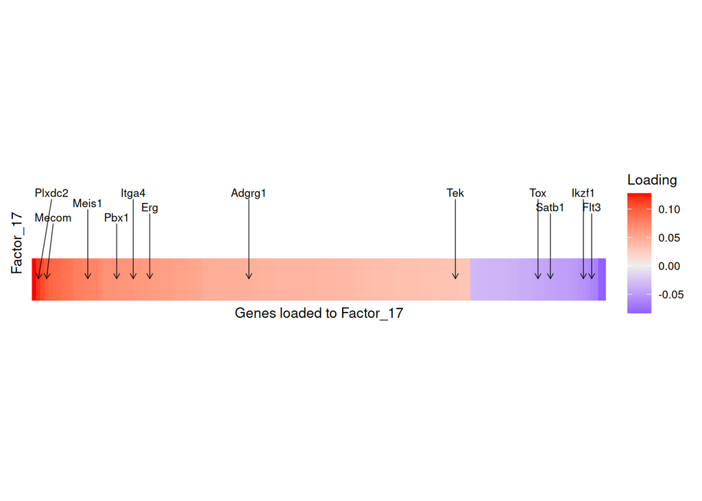

```r
Factor17_LT_HSC <- zoom_factor_heatmap_W(W_mat_21_sparse_flip, target_factor = "Factor_17",
                                               genes_to_label = c("Mecom", "Meis1", "Pbx1", "Tek", "Plxdc2",
                                                                  "Itga4", "Adgrg1","Erg","Tox","Flt3","Satb1","Ikzf1"), eps = 0.0)
Factor17_LT_HSC
```

```r
# Factor 12 = NFkB signalling
top_Factor_12 <- get_genes_for_factor("Factor_12", W_mat_21_sparse_flip, top=T)
top_Factor_12
```

```
##  [1] "Tnip1"       "Susd6"       "D17H6S56E-5" "Nfkbia"      "Tnip3"
##  [6] "Pde4b"       "Cd69"        "Tank"        "Stox2"       "Fyb1"
## [11] "Nadk"        "Birc3"       "Zeb2"        "Nfkb1"       "Kmt2a"
## [16] "Asap1"       "Tnfaip3"     "Dennd4a"     "Nfkbiz"      "Mapkapk2"
## [21] "Serpina3g"   "Adgrg1"      "St3gal1"     "Ugcg"        "St6galnac3"
## [26] "Pou2f2"      "Cd274"       "Arhgap6"     "Lyn"         "Apobec3"
## [31] "Nfkb2"       "Man1a"       "Kansl1l"     "Mink1"       "Gigyf2"
## [36] "Serinc3"     "Plek"        "Il1r1"       "Rel"         "Bcl11a"
## [41] "Muc13"       "Dapp1"       "Ly6e"        "Fam107b"     "Angpt1"
## [46] "Pim1"        "Ern1"        "Glipr1"      "Arhgef10l"   "Lyst"
## [51] "Serpina3f"   "Csf3r"       "Gramd1b"     "Nedd4"       "B2m"
## [56] "Adam17"      "Gimap6"      "Lypd6b"      "Dach1"       "Tet2"
## [61] "Shisa5"      "Icam1"       "Fmnl2"       "Znrf1"       "Tec"
## [66] "Zc3h12a"     "Calr"        "Samsn1"      "Vav2"        "Erdr1y"
## [71] "Arhgef3"     "Itgb3"       "Rora"        "Etv6"        "Dock10"
## [76] "Lratd2"      "Zfp710"      "Sgms1"       "Cep162"      "Cd55"
## [81] "Cd96"        "H2-K1"       "Abcc1"       "Actr3"       "Car2"
## [86] "Chd4"        "Prkcd"       "Hectd1"      "Nfat5"       "Daam1"
## [91] "Fchsd2"      "Zmiz2"       "Lims1"       "Osbpl8"      "Zfand3"
```

```r
bottom_Factor_12 <- get_genes_for_factor("Factor_12", W_mat_21_sparse_flip, top=F)
bottom_Factor_12
```

```
##  [1] "Hmga2"    "Map2k6"   "Runx2"    "Kcnq5"    "Pag1"     "Gfod1"
##  [7] "Prkag2"   "Zfp800"   "Rnf150"   "Ankrd44"  "Emb"      "Trerf1"
## [13] "Bcl2"     "Arhgef18" "Cers6"    "Zbtb16"   "Tns3"     "Ugt1a6a"
## [19] "Ikzf1"    "Aopep"    "Dgkg"     "Coro7"    "Cracr2a"  "Slc39a11"
## [25] "Enah"
```

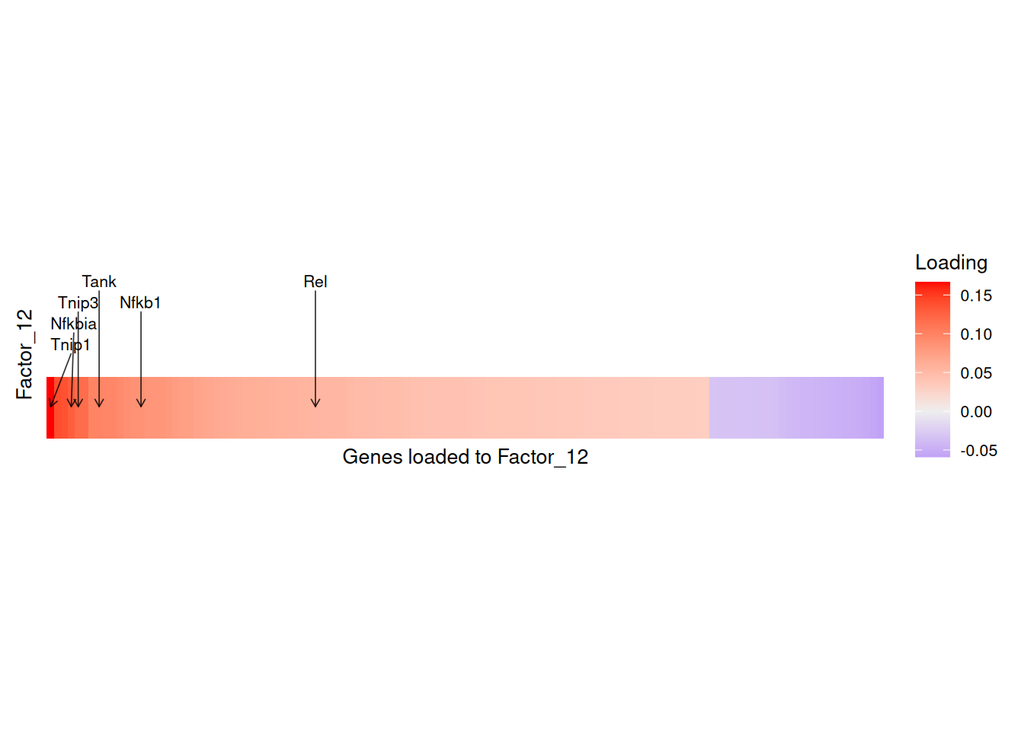

```r
Factor12_NFkB <- zoom_factor_heatmap_W(W_mat_21_sparse_flip, target_factor = "Factor_12",
                                       genes_to_label = c("Nfkbia","Nfkb1","Rel","Tnip3","Tnip1","Tank"), eps = 0.0)
Factor12_NFkB
```

```r
Factor12_NFkB_nolabel <- zoom_factor_heatmap_W(W_mat_21_sparse_flip,
                                               target_factor = "Factor_12",
                                               genes_to_label = NULL, eps = 0.0)

Factor17_LT_HSC_nolabel <- zoom_factor_heatmap_W(W_mat_21_sparse_flip,
                                                 target_factor = "Factor_17",
                                                 genes_to_label = NULL, eps = 0.0)

Factor20_biosynthesis_nolabel <- zoom_factor_heatmap_W(W_mat_21_sparse_flip,
                                                       target_factor = "Factor_20",
                                                       genes_to_label = NULL, eps = 0.0)
#Factor12_NFkB_nolabel
#Factor17_LT_HSC_nolabel
#Factor20_biosynthesis_nolabel
```

Save plots with labels:

```r
ggsave( filename = "manuscript/fig2/Factor12_NFkB_heatmap.pdf",
        plot     = Factor12_NFkB,
        width    = 8,
        height   = 4,
        units    = "in"
        )
ggsave( filename = "manuscript/fig2/Factor17_LT_HSC_heatmap.pdf",
        plot     = Factor17_LT_HSC,
        width    = 6,
        height   = 4,
        units    = "in"
        )
ggsave( filename = "manuscript/fig2/Factor20_biosynthesis_heatmap.pdf",
        plot     = Factor20_biosynthesis,
        width    = 8,
        height   = 4,
        units    = "in"
        )
```

Save plots without labels:

```r
ggsave( filename = "manuscript/fig2/Factor12_NFkB_heatmap_nolabel.pdf",
        plot     = Factor12_NFkB_nolabel,
        width    = 6,
        height   = 4,
        units    = "in"
        )
ggsave( filename = "manuscript/fig2/Factor17_LT_HSC_heatmap_nolabel.pdf",
        plot     = Factor17_LT_HSC_nolabel,
        width    = 6,
        height   = 4,
        units    = "in"
        )
ggsave( filename = "manuscript/fig2/Factor20_biosynthesis_heatmap_nolabel.pdf",
        plot     = Factor20_biosynthesis_nolabel,
        width    = 6,
        height   = 4,
        units    = "in"
        )
```

## 3.6 Find & plot representative genes for all factors

```r
zoom_factor_heatmap_W(W_mat_21_sparse_flip, target_factor = "Factor_1",
                      genes_to_label = c("Mpo","Ccl9","Plac8","Sell","Selp","Itgb3",
                                         "Grb10", "Clnk"), eps = 0.0)

zoom_factor_heatmap_W(W_mat_21_sparse_flip, target_factor = "Factor_2",
                      genes_to_label = c("Adgrl4", "Dock1","Flt3","Cd34",
                                         "Pcdh7"), eps = 0.0)

zoom_factor_heatmap_W(W_mat_21_sparse_flip, target_factor = "Factor_3",
                      genes_to_label = c("Egr1", "Malat1", "Neat1", "Jun", "Fos","Nfkbiz"), eps = 0.0)

zoom_factor_heatmap_W(W_mat_21_sparse_flip, target_factor = "Factor_4",
                      genes_to_label = c("Smim3", "Klf13","Egr1", "Jun","Spred2",
                                         "Erg","Itga4","Lmo2","Myb", "Adgrg1"), eps = 0.0)

# new "representative genes" from Lars
zoom_factor_heatmap_W(W_mat_21_sparse_flip, target_factor = "Factor_4",
                      genes_to_label = c("Rock1", "Mapkapk2", "Jun", "Junb", "Spred2", "Rasgef1b",
                                         "Kit", "Hlf", "Cd47", "Myb", "Itga4", "Lmo2"), eps = 0.0)

zoom_factor_heatmap_W(W_mat_21_sparse_flip, target_factor = "Factor_5",
                      genes_to_label = c("Itga2b","Itgb3","Myh9","Flna","Fyb1","Actb",
                                         "Cdk6","Mpo","Erg"), eps = 0.0)

zoom_factor_heatmap_W(W_mat_21_sparse_flip, target_factor = "Factor_6",
                      genes_to_label = c("Pola1", "Rad51b",
                                         "Mcm4","Mcm3","Mcm6",
                                         "Smc2","Smc6","Top2a"), eps = 0.0)

zoom_factor_heatmap_W(W_mat_21_sparse_flip, target_factor = "Factor_8",
                      genes_to_label = c("mt-Rnr1", "mt-Rnr2", "mt-Cytb", "mt-Nd1",
                                         "Cmss1","Lars2"), eps = 0.0)

zoom_factor_heatmap_W(W_mat_21_sparse_flip, target_factor = "Factor_9",
                      genes_to_label = c("Bcl11a", "Bach2", "Runx1", "Cbfa2t3","Plcg2",
                                         "Hspa5", "Hsp90b1", "Sec24d", "Pdia3","Ern1"), eps = 0.0)

zoom_factor_heatmap_W(W_mat_21_sparse_flip, target_factor = "Factor_11",
                      genes_to_label = c("Myc","Ccnd2","Eif4a1","Lars1","Eif4g1","Npm1","Eif2s2",
                                         "Ikzf2"), eps = 0.0)

zoom_factor_heatmap_W(W_mat_21_sparse_flip, target_factor = "Factor_12",
                      genes_to_label = c("Tnip1", "Nfkbia", "Tnip3", "Tank", "Tnfaip3", "Nfkb1", "Nfkbiz",
                                         "Hmga2", "Bcl2", "Runx2"), eps = 0.0)

zoom_factor_heatmap_W(W_mat_21_sparse_flip, target_factor = "Factor_13",
                      genes_to_label = c("Hmga2", "Hlf", "Cd53", "Msi2", "Runx2",
                                         "Scin", "Aff3"), eps = 0.0)

zoom_factor_heatmap_W(W_mat_21_sparse_flip, target_factor = "Factor_14",
                      genes_to_label = c("Kcnq5", "Immp2l", "Pard3b", "Elmo1", "Ncl", "Rad51b",
                                         "Cbfa2t3", "Pim1", "Adgrg1"), eps = 0.0)

# B-lymphoid priming gene signatures from Lars = less strong:
zoom_factor_heatmap_W(W_mat_21_sparse_flip, target_factor = "Factor_14",
                      genes_to_label = c("Tcf4", "Foxp1", "Maml3", "Ikzf2", "Mef2c", "Zeb2"), eps = 0.0)

zoom_factor_heatmap_W(W_mat_21_sparse_flip, target_factor = "Factor_15",
                      genes_to_label = c("Hexb", "Cdk8", "Mir6236", "Lars2", "Cmss1"),
                      eps = 0.0)

zoom_factor_heatmap_W(W_mat_21_sparse_flip, target_factor = "Factor_16",
                      genes_to_label = c("Fut8", "Wdfy4", "Ptprc", "Dock10",  "Plcg2", "Tespa1"), eps = 0.0)

zoom_factor_heatmap_W(W_mat_21_sparse_flip, target_factor = "Factor_17",
                      genes_to_label = c("Plxdc2", "Mecom", "Meis1",
                                         "Dach1", "Angpt1",
                                         "Flt3", "Ikzf1", "Satb1", "Emb"), eps = 0.0)

zoom_factor_heatmap_W(W_mat_21_sparse_flip, target_factor = "Factor_18",
                      genes_to_label = c("Cdk6", "Etv6","Msi2", "Mpo", "Myb","Kit","Erg"), eps = 0.0)

# new from Lars:
zoom_factor_heatmap_W(W_mat_21_sparse_flip, target_factor = "Factor_18",
                      genes_to_label = c("Mpo", "Myb", "Kit", "Flt3",
                                         "Runx1", "Ikzf2", "Mecom", "Lmo2"), eps = 0.0)

zoom_factor_heatmap_W(W_mat_21_sparse_flip, target_factor = "Factor_19",
                      genes_to_label = c("Plxdc2", "Lrp12", "Pcdh7", "Stox2",
                                         "Mecom", "Igf1r", "Myb", "Egr1", "Kit"), eps = 0.0)

zoom_factor_heatmap_W(W_mat_21_sparse_flip, target_factor = "Factor_20",
                      genes_to_label = c("Actb", "Rps18", "Rps5", "Npm1",
                                         "Rpl4", "Rps3", "Rps26"), eps = 0.0)

zoom_factor_heatmap_W(W_mat_21_sparse_flip, target_factor = "Factor_21",
                      genes_to_label = c("Mki67", "Kif15", "Kif11",
                                         "Top2a","Cenpe", "Cenpp", "Ncapg2","Ncapd2"),
                      eps = 0.0)
```

[output not shown]

## 3.7 GO enrichment of factors

- Some factors demonstrate clear GO enrichments for particular bioligical processes
- Repeating for the “geneontology_Molecular_Function_noRedundant” database did not generate further insight (besides enrichment of ‘rRNA binding’ and ‘structural constituent of ribosome’ in Factor_20)

```r
enrich_db <- "geneontology_Biological_Process_noRedundant"
listIdType(organism = "mmusculus")
```

```
##  [1] "ABI_550XL_Wildfire"                  "ABI_SOLiD"
##  [3] "ABI_SOLiD_Exon"                      "ABI_SOLiD_Klaus"
##  [5] "IonTorrent_RNASeqMature"             "MGI"
##  [7] "Protein_GeneChip34"                  "Protein_GeneChip41"
##  [9] "Protein_GeneChip51"                  "affy_ClariomD-MTA-1_0"
## [11] "affy_HTMG-430PM_GPL11180"            "affy_mg_u74a"
## [13] "affy_mg_u74av2"                      "affy_mg_u74b"
## [15] "affy_mg_u74bv2"                      "affy_mg_u74c"
## [17] "affy_mg_u74cv2"                      "affy_microRNA4"
## [19] "affy_moe430a"                        "affy_moe430b"
## [21] "affy_moex_1_0_st_v1"                 "affy_mogene_1_0_st_v1"
## [23] "affy_mogene_2_1_st_v1"               "affy_mouse430_2"
## [25] "affy_mouse430a_2"                    "affy_mu11ksuba"
## [27] "affy_mu11ksubb"                      "agilent_Custom_GPL2510"
## [29] "agilent_ToxicogenomicsG4121A_GPL891" "agilent_sureprint_g3_ge_8x60k"
## [31] "agilent_wholegenome"                 "agilent_wholegenome_4x44k_v1"
## [33] "agilent_wholegenome_4x44k_v2"        "codelink_codelink"
## [35] "dbSNP"                               "embl"
## [37] "ensembl_gene_id"                     "ensembl_peptide_id"
## [39] "entrezgene"                          "entrezgene_protein-coding"
## [41] "genename"                            "genesymbol"
## [43] "illumina_ScriptSeq_RNASeqV2"         "illumina_WG6_Customarray"
## [45] "illumina_mouseref_8"                 "illumina_mouseref_8_v2"
## [47] "illumina_mousewg_6_v1"               "illumina_mousewg_6_v2"
## [49] "interpro"                            "phalanx_onearray"
## [51] "phosphositeEnsembl"                  "phosphositeRefseq"
## [53] "phosphositeSeq"                      "phosphositeUniprot"
## [55] "protein_id"                          "refseq_mrna"
## [57] "refseq_peptide"                      "unigene"
## [59] "uniprotswissprot"
```

```r
all_genes <- rownames(gibbs_PM_21$F_pm)

# GO enrichment for all factors, "top" lists ----
enrich_res_top <- list()
for (i in setdiff(1:21, c(7, 10))) {
  # Factor_id
  factor_id <- paste0("Factor_", i)
  # Top genes (positively loaded to factor)
  genes_to_test_top <- get_genes_for_factor(factor_id, W_mat_21_sparse_flip, top=T)
  # Enrichment results
  enrich_res_top[[factor_id]] <- WebGestaltR::WebGestaltR(enrichMethod = "ORA",
                             organism = "mmusculus",
                             enrichDatabase = enrich_db,
                             interestGene = genes_to_test_top,
                             interestGeneType = "genesymbol",
                             referenceGene = all_genes,
                             referenceGeneType = "genesymbol",
                             isOutput = F)
}
```

```
## Loading the functional categories...
## Loading the ID list...
## Loading the reference list...
## Performing the enrichment analysis...
```

```
## Loading the functional categories...
## Loading the ID list...
## Loading the reference list...
## Performing the enrichment analysis...
```

```
## Loading the functional categories...
## Loading the ID list...
## Loading the reference list...
## Performing the enrichment analysis...
```

```
## Loading the functional categories...
## Loading the ID list...
## Loading the reference list...
## Performing the enrichment analysis...
```

[output not shown]

```
## Loading the functional categories...
## Loading the ID list...
## Loading the reference list...
## Performing the enrichment analysis...
```

[output not shown]

```
## Loading the functional categories...
## Loading the ID list...
## Loading the reference list...
## Performing the enrichment analysis...
```

```
## Loading the functional categories...
## Loading the ID list...
## Loading the reference list...
## Performing the enrichment analysis...
```

```
## Loading the functional categories...
## Loading the ID list...
## Loading the reference list...
## Performing the enrichment analysis...
```

[output not shown]

[output not shown]

```r
# GO enrichment for any "bottom genes" ----
enrich_res_bottom <- list()
for (i in setdiff(1:21, c(7, 10, 15, 21))) {
  # Factor_id
  factor_id <- paste0("Factor_", i)
  # Top genes (positively loaded to factor)
  genes_to_test_bottom <- get_genes_for_factor(factor_id, W_mat_21_sparse_flip, top=F)
  # Enrichment results
  enrich_res_bottom[[factor_id]] <- WebGestaltR::WebGestaltR(enrichMethod = "ORA",
                             organism = "mmusculus",
                             enrichDatabase = enrich_db,
                             interestGene = genes_to_test_bottom,
                             interestGeneType = "genesymbol",
                             referenceGene = all_genes,
                             referenceGeneType = "genesymbol",
                             isOutput = F)
}
```

```
## Loading the functional categories...
## Loading the ID list...
## Loading the reference list...
## Performing the enrichment analysis...
```

```
## Loading the functional categories...
## Loading the ID list...
## Loading the reference list...
## Performing the enrichment analysis...
```

```
## Loading the functional categories...
## Loading the ID list...
## Loading the reference list...
## Performing the enrichment analysis...
```

```
## Loading the functional categories...
## Loading the ID list...
## Loading the reference list...
## Performing the enrichment analysis...
```

```
## Loading the functional categories...
## Loading the ID list...
## Loading the reference list...
## Performing the enrichment analysis...
```

```
## Loading the functional categories...
## Loading the ID list...
## Loading the reference list...
## Performing the enrichment analysis...
```

```
## Loading the functional categories...
## Loading the ID list...
## Loading the reference list...
## Performing the enrichment analysis...
```

[output not shown]

```
## Loading the functional categories...
## Loading the ID list...
## Loading the reference list...
## Performing the enrichment analysis...
```

```
## Loading the functional categories...
## Loading the ID list...
## Loading the reference list...
## Performing the enrichment analysis...
```

```
## Loading the functional categories...
## Loading the ID list...
## Loading the reference list...
## Performing the enrichment analysis...
```

```
## Loading the functional categories...
## Loading the ID list...
## Loading the reference list...
## Performing the enrichment analysis...
```

```
## Loading the functional categories...
## Loading the ID list...
## Loading the reference list...
## Performing the enrichment analysis...
```

```
## Loading the functional categories...
## Loading the ID list...
## Loading the reference list...
## Performing the enrichment analysis...
```

```
## Loading the functional categories...
## Loading the ID list...
## Loading the reference list...
## Performing the enrichment analysis...
```

```
## Loading the functional categories...
## Loading the ID list...
## Loading the reference list...
## Performing the enrichment analysis...
```

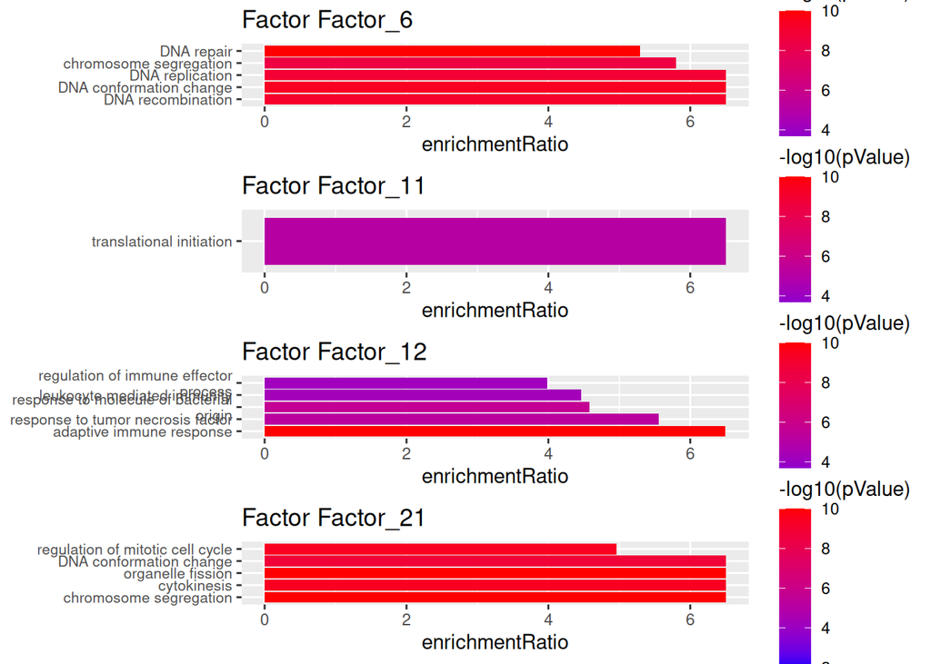

```r
# Plot some factors with obvious GO enrichments ----
factor_indices <- c("Factor_6","Factor_11","Factor_12","Factor_21")
plot_list <- list()
for (factor_indx in factor_indices) {

  # top terms for factor
  top_terms <- enrich_res_top[[factor_indx]]$description[1:5]

  # make bar plot
  p <- barplot_top_enrich_terms(
    enrich_res_top[[factor_indx]],
    terms_of_interest = top_terms,
    FC_cutoff = 1.5,
    FC_max = 6.5,
    str_wrap_length = 35
  ) + labs(title = paste0("Factor ", factor_indx))

  # add to  list
  plot_list[[length(plot_list) + 1]] <- p
}

# arrange and display
align_plot_widths <- function(plot_list) {
  grob_list <- lapply(plot_list, ggplotGrob)

  # compute the maximum width for each column across all grobs
  maxWidth <- Reduce(grid::unit.pmax, lapply(grob_list, function(g) g$widths))

  # assign that maxWidth to each grob
  grob_list <- lapply(grob_list, function(g) {
    g$widths <- maxWidth
    g
  })

  grob_list
}
aligned_grobs <- align_plot_widths(plot_list)
do.call(gridExtra::grid.arrange, c(aligned_grobs, ncol = 1))
```

# 4 How perturbations affect GRPs

## 4.1 Functions for perturbation effects

```r
# ---- Function to turn Beta and Gamma matrices into df ----
#' prep_effects
#'
#' @param beta  numeric matrix (guides/perturbations x factors), row/colnames required
#' @param gamma numeric matrix (same dimnames as beta) of posterior inclusion probabilities
#' @param factor_annotation optional data.frame with columns: factor_id (must match colnames),
#'        factor_label (descriptive name), multiply_with (numeric +/-1 to align signs)
#' @param gamma_thresh PIP threshold used to flag significant entries (default 0.8)
#' @param align_sign multiply beta by the multiply_with column in factor_annotation to ensure consistent directions of perturbation effects
#' @param id_simplify whether to simplify names of IDs to replace id_pattern with id_replacement
#' @return data.frame in long/tidy form with columns: perturbation, factor_id, beta, gamma,
#'         sig, factor_label, multiply_with, beta_aligned
prep_effects <- function(beta, gamma, factor_annotation = NULL,
                         gamma_thresh = 0.8, align_sign = TRUE,
                         id_simplify = FALSE,
                         id_pattern = "-CRISPRi-sgRNA-",
                         id_replacement = ".",
                         gene_regex = "-CRISPRi-sgRNA-[1-3]$") {
  # Input checks ----
  stopifnot(is.matrix(beta), is.matrix(gamma))
  stopifnot(identical(rownames(beta), rownames(gamma)))
  stopifnot(identical(colnames(beta), colnames(gamma)))

  # Melt + merge ----
  df_beta  <- reshape2::melt(beta, varnames = c("perturbation", "factor_id"), value.name = "beta")
  df_gamma <- reshape2::melt(gamma, varnames = c("perturbation", "factor_id"), value.name = "gamma")
  df <- merge(df_beta, df_gamma, by = c("perturbation", "factor_id"), all.x = TRUE)
  df$gamma[is.na(df$gamma)] <- 0
  df$sig <- df$gamma >= gamma_thresh

  # Derive perturbed_gene (pre-normalization) ----
  df$perturbed_gene <- sub(gene_regex, "", df$perturbation)

  # Optional ID normalization for display ----
  if (isTRUE(id_simplify)) {
    df$perturbation <- gsub(id_pattern, id_replacement, df$perturbation)
  }

  # Attach factor labels & alignment metadata ----
  if (!is.null(factor_annotation)) {
    fa <- factor_annotation
    if (!"factor_label" %in% names(fa)) fa$factor_label <- fa$factor_id
    if (!"multiply_with" %in% names(fa)) fa$multiply_with <- 1
    df <- merge(df, fa[, c("factor_id", "factor_label", "multiply_with")], by = "factor_id", all.x = TRUE)
  } else {
    df$factor_label  <- df$factor_id
    df$multiply_with <- 1
  }

  # Sign alignment ----
  if (align_sign) {
    df$beta_aligned <- df$beta * ifelse(is.na(df$multiply_with), 1, df$multiply_with)
  } else {
    df$beta_aligned <- df$beta
  }
  # Remove "offset" from GSFA ----
  df <- subset(df, !perturbation == "offset")
  # Return ----
  df
}

# ---- Function to plot effects of genes on a given factor ----

#' plot_factor_effects
#' @param effects_long output of prep_effects()
#' @param factor one factor ID present in effects_long$factor_id (e.g., "Factor_12")
#' @param genes genes to plot (e.g., c("Myc","Max))
#' @param clamp numeric; clamp effect to ±clamp for stability in visuals (default 2)
#' @param point_size_max maximum size for size=PIP scale
plot_factor_effects <- function(effects_long, factor, genes = NULL,
                                clamp = 2, gene_colors = NULL,
                                size_breaks = c(0.25, 0.5, 0.75, 1),
                                point_size_max = 6,
                                collapse_y = FALSE,
                                show_PIP_legend = TRUE,
                                x_limits = NULL
                                ) {
  d <- subset(effects_long, factor_id == factor)
  if (!is.null(genes)) d <- d[d$perturbed_gene %in% genes, , drop = FALSE]
  if (nrow(d) == 0) stop("No rows left to plot after subsetting.")

  # Inline clamp (symmetric) ----
  if (is.null(clamp) || !is.finite(clamp)) {
    d$beta_plot <- d$beta_aligned
  } else {
    lim <- abs(clamp)
    d$beta_plot <- pmin(pmax(d$beta_aligned, -lim), lim)
  }

  # y axis: either per-gene levels (group guides) or a single collapsed line
  if (isTRUE(collapse_y)) {
    d$y_axis <- factor("perturbations")
  } else {
    ord_df <- plyr::ddply(d, "perturbed_gene",
                          summarise, m = mean(abs(beta_aligned), na.rm = TRUE))
    d$perturbed_gene <- factor(
      d$perturbed_gene,
      levels = ord_df$perturbed_gene[order(-ord_df$m)]
    )
    d$y_axis <- d$perturbed_gene
  }

  p <- ggplot(d, aes(y = y_axis, x = beta_plot)) +
    geom_vline(xintercept = 0, linetype = 3) +
    geom_point(aes(size = gamma, color = perturbed_gene, alpha = sig)) +
    scale_size_area(
      max_size = point_size_max,
      name     = "PIP",
      breaks   = size_breaks,
      limits   = c(0, 1),
      guide    = if (show_PIP_legend) "legend" else "none"   # <- NEW
    ) +
    scale_alpha_manual(values = c(`FALSE` = 0.5, `TRUE` = 1), guide = "none") +
    theme_bw() + theme(panel.grid = element_blank()) +
    labs(x = "Effect on program (β; sign-aligned)", y = NULL,
         title = ifelse(length(unique(d$factor_label)) == 1,
                        unique(d$factor_label), factor))

  # Color mapping: use provided named vector (gene → color). If not provided, fall back to Set1.
  if (is.null(gene_colors)) {
    p <- p + scale_color_brewer(palette = "Set1", name = "Gene")
  } else {
    present <- intersect(names(gene_colors), unique(as.character(d$perturbed_gene)))
    vals <- gene_colors[present]
    p <- p + scale_color_manual(values = vals, name = "Gene", na.value = "grey70")
  }

  # Optional x-axis limits
  if (!is.null(x_limits)) {
    p <- p + scale_x_continuous(limits = x_limits)
    # or coord_cartesian(xlim = x_limits) if you prefer to crop without dropping data
  }

  # Hide y-axis text/ticks when collapsed
  if (isTRUE(collapse_y)) {
    p <- p + theme(axis.text.y = element_blank(), axis.ticks.y = element_blank())
  }

  p
}


# ---- Function to plot one perturbation across all factors ----
plot_perturbation_profile <- function(effects_long,
                                      perturbation,
                                      factors = NULL,
                                      clamp = 2,
                                      label_top = FALSE) {
  d <- effects_long[effects_long$perturbation == perturbation, , drop = FALSE]
  if (!is.null(factors)) d <- d[d$factor_id %in% factors, , drop = FALSE]
  if (nrow(d) == 0) stop("No rows left to plot after subsetting.")
```

```r
  # Inline clamp (symmetric) ----
  if (is.null(clamp) || !is.finite(clamp)) {
    d$beta_plot <- d$beta_aligned
    } else {
      lim <- abs(clamp)
      d$beta_plot <- pmin(pmax(d$beta_aligned, -lim), lim)
    }

  # Use factor_id for y-order to avoid duplicate label issues
  ord <- order(d$beta_aligned)
  d$factor_id <- factor(d$factor_id, levels = d$factor_id[ord])

  # Pretty labels mapping
  pretty_labels <- ifelse(is.na(d$factor_label), as.character(d$factor_id), as.character(d$factor_label))
  label_map <- setNames(pretty_labels, as.character(d$factor_id))

  p <- ggplot(d, aes(x = beta_plot, y = factor_id)) +
    geom_vline(xintercept = 0, linetype = 3) +
    geom_point(aes(size = gamma, alpha = sig, color = beta_aligned > 0)) +
    scale_size_area(max_size = 3, name = "PIP") +
    scale_alpha_manual(values = c(`FALSE` = 0.2, `TRUE` = 1), guide = "none") +
    scale_color_brewer(palette = "Set1", guide = "none") +
    scale_y_discrete(labels = label_map, name = "Factor") +
    theme_bw() + theme(panel.grid = element_blank()) +
    labs(x = "Effect on program (β; sign-aligned)", title = perturbation)
  p
  }


# ---- Function to plot one or more genes across factors (all guides) ----
plot_perturbation_profile_gene <- function(effects_long,
                                           perturbed_genes,             # e.g. c("Myc","Max")
                                           factors = NULL,              # optional subset of factors to include
                                           exclude_factors = NULL,      # factors to remove explicitly
                                           auto_exclude_nonsig = FALSE, # remove factor if *all* rows have sig==FALSE
                                           min_sig_per_factor = NULL,   # min # of significant guides per factor
                                           clamp = 2,                   # clamp |beta| for plotting
                                           gene_colors = NULL,          # named vector gene->color
                                           max_size = 6) {              # control dot size scale (PIP)
  # subset df of perturbation effects to the perturbed_genes
  d <- effects_long[effects_long$perturbed_gene %in% perturbed_genes, , drop = FALSE]
  if (!is.null(factors))         d <- d[d$factor_id %in% factors, , drop = FALSE]
  if (!is.null(exclude_factors)) d <- d[!d$factor_id %in% exclude_factors, , drop = FALSE]
  if (nrow(d) == 0) stop("No rows left to plot after subsetting.")

  if (!("sig" %in% names(d))) {
    stop("Effects dataframe must contain a logical 'sig' column.")
  }

  # Logical significance (NA treated as FALSE)
  d$sig_logical <- !is.na(d$sig) & as.logical(d$sig)

  # ------------------------------------------------------------------
  # 1) Drop (perturbed_gene, factor_id) groups where ALL guides are non-significant
  # ------------------------------------------------------------------
  gf_tbl <- aggregate(sig_logical ~ perturbed_gene + factor_id, data = d, FUN = any)
  gf_tbl$key <- paste(gf_tbl$perturbed_gene, gf_tbl$factor_id, sep = "||")
  keep_pairs <- gf_tbl$key[gf_tbl$sig_logical]

  pair_key_all <- paste(d$perturbed_gene, d$factor_id, sep = "||")
  d <- d[pair_key_all %in% keep_pairs, , drop = FALSE]

  if (nrow(d) == 0) {
    stop("No significant guides in any (gene, factor) combination.")
  }

  # ------------------------------------------------------------------
  # 2) Factor-level threshold: drop factors with too few significant guides
  # ------------------------------------------------------------------
  if (!is.null(min_sig_per_factor) || isTRUE(auto_exclude_nonsig)) {
    # Choose threshold:
    # - if min_sig_per_factor is set, use that
    # - else if auto_exclude_nonsig is TRUE, require at least 1 significant guide
    if (!is.null(min_sig_per_factor)) {
      thresh <- as.integer(min_sig_per_factor)
      if (is.na(thresh) || thresh < 1L) {
        stop("min_sig_per_factor must be a positive integer.")
      }
    } else {
      thresh <- 1L  # auto_exclude_nonsig behaviour
    }

    fac_tbl <- aggregate(sig_logical ~ factor_id, data = d, FUN = sum)  # count of TRUE per factor
    keep_factors <- as.character(fac_tbl$factor_id[fac_tbl$sig_logical >= thresh])

    d <- d[d$factor_id %in% keep_factors, , drop = FALSE]
    if (nrow(d) == 0) {
      stop("No rows left after excluding low-significance factors.")
    }
  }

  # (optional) drop helper column
  d$sig_logical <- NULL

  # ------------------------------------------------------------------
  # 3) Clamp (symmetric) and plotting (unchanged)
  # ------------------------------------------------------------------
  if (is.null(clamp) || !is.finite(clamp)) {
    d$beta_plot <- d$beta_aligned
  } else {
    lim <- abs(clamp)
    d$beta_plot <- pmin(pmax(d$beta_aligned, -lim), lim)
  }

  # Factor axis: numeric order (Factor_1, Factor_2, ...)
  fnum <- suppressWarnings(as.integer(gsub("\\D", "", as.character(d$factor_id))))
  ord_idx <- order(fnum, d$factor_id, na.last = TRUE)
  levs <- unique(d$factor_id[ord_idx])
  d$factor_id <- factor(d$factor_id, levels = rev(levs))

  # Pretty label map (one label per level)
  lab_df <- unique(d[, c("factor_id", "factor_label")])
  lab_df$lab <- ifelse(is.na(lab_df$factor_label),
                       as.character(lab_df$factor_id),
                       as.character(lab_df$factor_label))
  label_map <- setNames(lab_df$lab, as.character(lab_df$factor_id))

  # Plot: size = PIP; color = gene; alpha by significance
  p <- ggplot(d, aes(x = beta_plot, y = factor_id)) +
    geom_vline(xintercept = 0, linetype = 3) +
    geom_point(aes(size = gamma, alpha = sig, color = perturbed_gene)) +
    scale_size_area(max_size = max_size, name = "PIP") +
    scale_alpha_manual(values = c(`FALSE` = 0.4, `TRUE` = 1), guide = "none") +
    scale_y_discrete(labels = label_map) +
    theme_bw() + theme(panel.grid = element_blank()) +
    labs(x = "Effect on program (sign-aligned β)",
         title = paste0(paste(unique(d$perturbed_gene), collapse = ", "), " guides"))
```

```r
  # Gene colors
  if (is.null(gene_colors)) {
    p <- p + scale_color_brewer(palette = "Set1", name = "Gene")
  } else {
    present <- intersect(names(gene_colors), unique(as.character(d$perturbed_gene)))
    p <- p + scale_color_manual(values = gene_colors[present], name = "Gene")
  }

  p
}

plot_perturbation_profile_gene_grey <- function(effects_long,
                                           perturbed_genes,
                                           factors = NULL,
                                           exclude_factors = NULL,
                                           factor_order = NULL,
                                           auto_exclude_nonsig = FALSE,
                                           min_sig_per_factor = NULL,
                                           clamp = 2,
                                           gene_colors = NULL,
                                           max_size = 6) {
  d <- effects_long[effects_long$perturbed_gene %in% perturbed_genes, , drop = FALSE]
  if (!is.null(factors))         d <- d[d$factor_id %in% factors, , drop = FALSE]
  if (!is.null(exclude_factors)) d <- d[!d$factor_id %in% exclude_factors, , drop = FALSE]
  if (nrow(d) == 0) stop("No rows left to plot after subsetting.")

  if (!("sig" %in% names(d))) stop("Effects dataframe must contain a logical 'sig' column.")

  d$sig_logical <- !is.na(d$sig) & as.logical(d$sig)

  gf_tbl <- aggregate(sig_logical ~ perturbed_gene + factor_id, data = d, FUN = any)
  gf_tbl$key <- paste(gf_tbl$perturbed_gene, gf_tbl$factor_id, sep = "||")
  keep_pairs <- gf_tbl$key[gf_tbl$sig_logical]

  pair_key_all <- paste(d$perturbed_gene, d$factor_id, sep = "||")
  d <- d[pair_key_all %in% keep_pairs, , drop = FALSE]
  if (nrow(d) == 0) stop("No significant guides in any (gene, factor) combination.")

  if (!is.null(min_sig_per_factor) || isTRUE(auto_exclude_nonsig)) {
    if (!is.null(min_sig_per_factor)) {
      thresh <- as.integer(min_sig_per_factor)
      if (is.na(thresh) || thresh < 1L) stop("min_sig_per_factor must be a positive integer.")
    } else {
      thresh <- 1L
    }

    fac_tbl <- aggregate(sig_logical ~ factor_id, data = d, FUN = sum)
    keep_factors <- as.character(fac_tbl$factor_id[fac_tbl$sig_logical >= thresh])

    d <- d[d$factor_id %in% keep_factors, , drop = FALSE]
    if (nrow(d) == 0) stop("No rows left after excluding low-significance factors.")
  }

  d$sig_logical <- NULL

  if (is.null(clamp) || !is.finite(clamp)) {
    d$beta_plot <- d$beta_aligned
  } else {
    lim <- abs(clamp)
    d$beta_plot <- pmin(pmax(d$beta_aligned, -lim), lim)
  }

  if (!is.null(factor_order)) {
    # manual order (top to bottom in plot)
    d$factor_id <- factor(d$factor_id, levels = rev(factor_order))
  } else {
    # existing automatic ordering
    fnum <- suppressWarnings(as.integer(gsub("\\D", "", as.character(d$factor_id))))
    ord_idx <- order(fnum, d$factor_id, na.last = TRUE)
    levs <- unique(d$factor_id[ord_idx])
    d$factor_id <- factor(d$factor_id, levels = rev(levs))
  }

  lab_df <- unique(d[, c("factor_id", "factor_label")])
  lab_df$lab <- ifelse(is.na(lab_df$factor_label),
                       as.character(lab_df$factor_id),
                       as.character(lab_df$factor_label))
  label_map <- setNames(lab_df$lab, as.character(lab_df$factor_id))

  # --- color key that greys out non-significant points
  d$color_key <- ifelse(as.logical(d$sig), as.character(d$perturbed_gene), "Non-significant")
  d$color_key <- factor(
    d$color_key,
    levels = c("Non-significant", sort(unique(as.character(d$perturbed_gene))))
  )

  p <- ggplot(d, aes(x = beta_plot, y = factor_id)) +
    geom_vline(xintercept = 0, linetype = 3) +
    geom_point(aes(size = gamma, alpha = sig, color = color_key)) +
    scale_size_area(max_size = max_size, name = "PIP") +
    scale_alpha_manual(values = c(`FALSE` = 0.4, `TRUE` = 1), guide = "none") +
    scale_y_discrete(labels = label_map) +
    theme_bw() + theme(panel.grid = element_blank()) +
    labs(x = "Effect on program (sign-aligned β)",
         title = paste0(paste(unique(d$perturbed_gene), collapse = ", "), " guides"))

  # Colors: grey for non-sig + gene palette/manual, and keep legend as Gene
  if (is.null(gene_colors)) {
    gene_levels <- sort(unique(as.character(d$perturbed_gene)))
    gene_pal <- setNames(scales::hue_pal()(length(gene_levels)), gene_levels)
    p <- p + scale_color_manual(
      values = c("Non-significant" = "grey70", gene_pal),
      breaks = gene_levels,
      name = "Gene"
    )
  } else {
    present <- intersect(names(gene_colors), unique(as.character(d$perturbed_gene)))
    p <- p + scale_color_manual(
      values = c("Non-significant" = "grey70", gene_colors[present]),
      breaks = present,
      name = "Gene"
    )
  }

  p
}

# ---- Function to plot heatmap of perturbation effects on factors (from GSFA paper Github) ----
dotplot_beta_PIP <- function(beta_pip_matrix, beta_pm_matrix,
                             marker_names, reorder_markers = marker_names,
                             reorder_factors = NULL,
                             remove_factors = NULL,
                             exclude_offset = TRUE,
                             inverse_factors = TRUE,
                             return_dataframe = FALSE,
                             color_lgd_title = "Estimated effect size"){
  # Both 'beta_pip_matrix' and 'beta_pm_matrix' should be factor by guide/marker matrices,
  # Dots will be colored by effect size and sized by PIP value.

  if (exclude_offset){
    beta_pip_matrix <- beta_pip_matrix[, -ncol(beta_pip_matrix)]
    beta_pm_matrix  <- beta_pm_matrix[,  -ncol(beta_pm_matrix)]
  }

  # ---- PIP ----
  rownames(beta_pip_matrix) <- 1:nrow(beta_pip_matrix)
  colnames(beta_pip_matrix) <- marker_names
  beta_pip_matrix <- beta_pip_matrix[, reorder_markers, drop = FALSE]

  beta_pip_df <- as.data.frame(beta_pip_matrix)
  beta_pip_df$Factor <- paste0("Factor ", 1:nrow(beta_pip_df))

  if (!is.null(reorder_factors)){
    beta_pip_df <- beta_pip_df[reorder_factors, , drop = FALSE]
  }
```

```r
  #remove named factors
  if (!is.null(remove_factors)){
    beta_pip_df <- beta_pip_df[!(beta_pip_df$Factor %in% remove_factors), , drop = FALSE]
  }

  beta_pip_plot_df <- reshape2::melt(beta_pip_df, value.name = "PIP")

  # ---- PM ----
  rownames(beta_pm_matrix) <- 1:nrow(beta_pm_matrix)
  colnames(beta_pm_matrix) <- marker_names
  beta_pm_matrix <- beta_pm_matrix[, reorder_markers, drop = FALSE]

  beta_pm_df <- as.data.frame(beta_pm_matrix)
  beta_pm_df$Factor <- paste0("Factor ", 1:nrow(beta_pm_df))

  if (!is.null(reorder_factors)){
    beta_pm_df <- beta_pm_df[reorder_factors, , drop = FALSE]
  }

  # remove named factors from PM
  if (!is.null(remove_factors)){
    beta_pm_df <- beta_pm_df[!(beta_pm_df$Factor %in% remove_factors), , drop = FALSE]
  }

  beta_pm_plot_df <- reshape2::melt(beta_pm_df, id.var = "Factor",
                                   variable.name = "Perturbation",
                                   value.name = "Estimated effect size")

  beta_pm_plot_df <- beta_pm_plot_df %>%
    dplyr::mutate(
      PIP = beta_pip_plot_df$PIP,
      Perturbation = factor(Perturbation, levels = reorder_markers)
    )

  if (inverse_factors){
    beta_pm_plot_df <- beta_pm_plot_df %>%
      dplyr::mutate(Factor = factor(Factor, levels = rev(beta_pip_df$Factor)))
  } else {
    beta_pm_plot_df <- beta_pm_plot_df %>%
      dplyr::mutate(Factor = factor(Factor, levels = beta_pip_df$Factor))
  }

  beta_pm_plot_df$`Estimated effect size`[beta_pm_plot_df$`Estimated effect size` > 0.8]  <- 0.8
  beta_pm_plot_df$`Estimated effect size`[beta_pm_plot_df$`Estimated effect size` < -0.8] <- -0.8

  if (isTRUE(return_dataframe)){
    return(beta_pm_plot_df)
  }

  plot_out <- ggplot2::ggplot(beta_pm_plot_df) +
    ggplot2::geom_point(ggplot2::aes(x = Perturbation, y = Factor,
                                     size = PIP, color = `Estimated effect size`)) +
    ggplot2::scale_color_gradientn(
      limits = c(-0.8, 0.8),
      colours = c("purple3", "purple1", "grey90", "darkorange", "darkorange2"),
      breaks = seq(-0.8, 0.8, 0.4)
    ) +
    ggplot2::scale_x_discrete(labels = function(x) gsub("-CRISPRi-sgRNA", "", x)) +
    ggplot2::scale_size_continuous(
      name   = "PIP",
      breaks = c(0, 0.5, 1),
      labels = c("0", "0.5", "1"),
      limits = c(0, 1)
    ) +
    ggplot2::theme_void() +
    ggplot2::theme(
      axis.text.x   = ggplot2::element_text(size = 13, angle = 90, hjust = 1),
      axis.text.y   = ggplot2::element_text(size = 13, hjust = 1),
      legend.title  = ggplot2::element_text(size = 13),
      legend.text   = ggplot2::element_text(size = 12),
      plot.margin   = ggplot2::margin(10, 10, 10, 12)
    ) +
    ggplot2::labs(color = color_lgd_title)

  return(plot_out)
}



# ---- Function to plot jittered points plot for a single factor ----
plot_factor_jitter <- function(effects_long,
                               factor,                      # e.g. "Factor_12"
                               highlight_genes = NULL,      # e.g. c("Myc","Max")
                               gene_colors = NULL,          # named vector: c(Myc="#8B0000", Max="#FF0000")
                               clamp = 2,                   # clamp |beta| for plotting
                               jitter_width = 0.15,         # horizontal jitter
                               bg_color = "grey70",         # background (non-highlight) point color
                               bg_size = 1.8,               # background point size
                               hl_size = 2.6,               # highlight point size
                               stroke_hl = 0.35) {          # black outline width for highlights

  # Subset to the factor
  d <- effects_long[effects_long$factor_id == factor, , drop = FALSE]
  if (nrow(d) == 0) stop("No rows for the requested factor.")

  # X label (use pretty label if available)
  x_lab <- if (!all(is.na(d$factor_label)) && length(unique(d$factor_label)) == 1) {
    as.character(unique(d$factor_label))
  } else {
    factor
  }
  d$._x <- factor(x_lab, levels = x_lab)  # single x category

  # Clamp beta for plotting
  if (is.null(clamp) || !is.finite(clamp)) {
    d$beta_plot <- d$beta_aligned
  } else {
    lim <- abs(clamp)
    d$beta_plot <- pmin(pmax(d$beta_aligned, -lim), lim)
  }

  # Background: all points in grey, alpha by significance (FALSE = 0.5, TRUE = 1)
  p <- ggplot(d, aes(x = ._x, y = beta_plot)) +
    geom_hline(yintercept = 0, linetype = 3) +
    geom_point(aes(alpha = sig),
               color = bg_color, size = bg_size,
               position = position_jitter(width = jitter_width, height = 0)) +
    scale_alpha_manual(values = c(`FALSE` = 0.5, `TRUE` = 1), guide = "none") +
    labs(x = NULL, y = "Effect on program (β; sign-aligned)", title = x_lab) +
    theme_bw() + theme(panel.grid = element_blank())

  # Overlay: highlighted genes in color, bigger, with a thin black outline (shape 21)
  if (!is.null(highlight_genes) && length(highlight_genes)) {
    present <- intersect(highlight_genes, unique(as.character(d$perturbed_gene)))
    if (length(present)) {
      d_hl <- d[d$perturbed_gene %in% present, , drop = FALSE]
      p <- p +
        geom_point(aes(fill = perturbed_gene, alpha = sig),
                   data = d_hl,
                   color = "black", stroke = stroke_hl, size = hl_size, shape = 21,
                   alpha = 1,
                   position = position_jitter(width = jitter_width, height = 0)) +
        (if (is.null(gene_colors)) {
           scale_fill_brewer(palette = "Set1", name = "Gene")
         } else {
           scale_fill_manual(values = gene_colors[present], name = "Gene")
         })
    }
  }

  p
}
# ---- Function to plot points plot for a single factor, arranged by complex ----
plot_factor_bycomplex <- function(effects_long,
                                  factor,
                                  highlight_genes = NULL,
                                  gene_colors = NULL,
                                  clamp = 2,
                                  sep_col = "perturbed_complex",
                                  bg_size_sig = 2.2,
                                  bg_size_nonsig = 1.4,
                                  hl_size = 2.8,
                                  stroke_hl = 0.35,
                                  other_label = "Other",
                                  other_color = "grey70",
                                  drop_all_nonsig_genes = FALSE,
                                  show_color_legend = TRUE) {
```